# Local LLMs vs OpenAI API: Political-Science Classification Benchmark (10 tasks, N=500, v2)

Published

April 26, 2026

## TL;DR

**10 classification tasks × 6 models × N=500 items per task = 30,000 predictions.** The v2 grid (2026-04-25) doubled v1’s N=250 by carrying over v1 predictions on the original 250 items and running the 4 Ollama models on 250 *additional* disjoint items each, plus running two new OpenAI tiers (`gpt-5.5` flagship + `gpt-5.4-nano` baseline, both at `reasoning_effort=medium`) on the full 500. v1’s `gpt-5.4` was retired with the v1 archive. Headline metrics carry paired-by-item bootstrap CIs (1000 iterations, 95%), MCC alongside macro F1 (handles class imbalance better), and per-correct-prediction cost columns. Total OpenAI cost for the v2 tier: **$22.86** ($21.66 gpt-5.5 + $1.20 gpt-5.4-nano).

### Findings

**Finding 1 — gpt-5.5 has the highest point estimate on 5 of 10 tasks**, narrowly leading mean F1 (0.621 vs Gemma 4 31B 0.619 — a 0.002-point lead). Wins: SemEval, Gilardi relevance, BFRS, CMP, BES. Gemma takes Ballard + Gilardi stance (2). Qwen3-14B takes CCC + SCOTUS (2). gpt-5.4-nano takes Wesleyan ad tone (1). Under the 95% bootstrap CI tie rule, the top group is still wide on most tasks — only Gilardi relevance distinguishes a clear top (2 of 6 models tied). Tasks 2–10 still have 5–6 models tied with the top point estimate (Tab. winners, Fig. 2).

**Finding 2 — The cross-model gap is smaller at N=500 than v1 implied.** Top 5 models cluster within 0.05 mean F1: gpt-5.5 0.621, Gemma 4 31B 0.619, gpt-5.4-nano 0.600, Mistral Sm 24B 0.590, Qwen3-14B 0.579. Only Qwen3-30B-A3B (0.569) trails by more than 0.05. **gpt-5.4-nano with `reasoning_effort=medium` jumped from worst-in-grid in v1 (default reasoning) to 3rd in v2** — explicit medium reasoning helped the small API tier more than any other change in this round (Fig. leaderboard).

**Finding 4 — MCC reveals BES MII is the *easiest* task in the grid, not the hardest.** Macro F1 on BES is 0.37–0.55, suggesting a hard 50-class problem; but accuracy is **0.93–0.95** and **MCC is 0.93** for the top model. Macro F1 was almost entirely rare-class noise (38% of items are Coronavirus; most other classes have <10 items in the test set). MCC handles this imbalance cleanly. The same pattern holds milder for Wesleyan ad tone (F1 0.71, accuracy 0.92, MCC 0.81) and Ballard incivility (F1 0.52, accuracy 0.85, MCC 0.45). For imbalanced tasks, **macro F1 alone is the wrong headline metric**.

**Finding 5 — Zero parse errors across 30,000 v2 predictions** (one single-item failure on qwen3:30b-a3b × BES carried over from v1). Strict JSON schema on the OpenAI tier with `reasoning_effort=medium` and the JSON-with-bare-label fallback on Ollama both held up across 12-class and 50-class label spaces (Tab. summary).

## Tasks

Prompt provenance: Verbatim = unchanged from source paper; Verbatim-adapted = source content with format-only adaptations (single-item, JSON tail, label subset to gold); Derived = no LLM prompt in source paper, ours reasoned from codebook/literature. See `docs/prompts_provenance.md` for per-task detail.

| Task | Paper | Type | Labels | Prompt provenance |
| --- | --- | --- | --- | --- |
| Gilardi relevance | Gilardi et al. 2023 PNAS | Binary | relevant/not | Verbatim |
| Gilardi stance | Gilardi et al. 2023 PNAS | 3-class | pro/neutral/contra | Verbatim |
| CCC protest type | Halterman & Keith 2025 PA | 4-class | PROTEST/RALLY/DEMONSTRATION/MARCH | Verbatim-adapted |
| BFRS violence | Halterman & Keith 2025 PA | 12-class | ASSASSINATION/TERRORISM/… | Verbatim-adapted |
| BES MII | Mellon et al. 2024 R&P | 50-class | Coronavirus/health/economy-general/… | Verbatim-adapted |
| Ballard incivility | Ballard 2022 LSQ | Binary | uncivil/not | Derived |
| SCOTUS sentiment | Ornstein et al. 2025 PSRM | 3-class | Positive/Negative/Neutral | Derived |
| SemEval 2016 stance | Chae & Davidson 2025 SMR | 3-class | FAVOR/AGAINST/NONE | Derived |
| CMP manifestos | Halterman & Keith 2025 PA + CMP | 7-class | Economy/Welfare/… | Derived |
| Wesleyan ad tone | Zhang et al. 2025 Sci Data / WMP | 3-class | promote/attack/unclear | Derived |

**NoteModels reference (collapsed by default)**

| Model | Role | Size | Arch |
| --- | --- | --- | --- |
| gemma4:31b-it-q4_K_M | open-weight | 31B dense | Transformer |
| qwen3:14b-q4_K_M | open-weight | 14B dense | Transformer |
| qwen3:30b-a3b-q4_K_M | open-weight | 30B MoE (3B active) | MoE |
| mistral-small:24b-instruct-2501-q4_K_M | open-weight | 24B dense | Transformer |
| gpt-5.4-nano | API baseline (cheapest) | undisclosed | Transformer |
| gpt-5.5 (reasoning_effort=medium) | API flagship | undisclosed | Transformer |

**NoteFigure 1 — ΔF1 vs gpt-5.4-nano baseline (collapsed by default)**

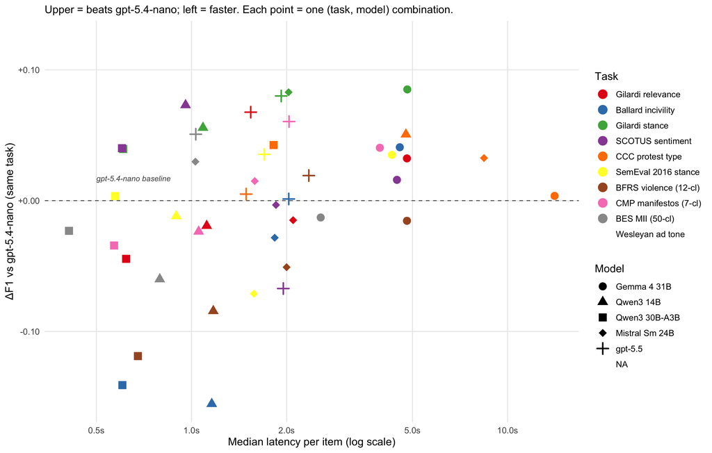

Figure 1: Performance delta vs median latency for 5 non-baseline models across 10 tasks (50 points total). The horizontal dashed line is gpt-5.4-nano: above = beats the baseline on that task, below = worse. Log-scale x-axis.

**Reading this figure (v2):** (note that per-task ΔF1 differences are mostly within the bootstrap-CI envelope shown in Fig. 2; treat the patterns below as point-estimate descriptions, not statistical tests):

- **gpt-5.5** has the highest mean ΔF1 vs nano on point estimate, driven by SemEval, Gilardi relevance, BFRS, CMP, and BES.
- **Gemma 4 31B** sits at the slow end (median 4.68 s/item) with mean F1 essentially tied with gpt-5.5 (0.619 vs 0.621). Top point estimates on Ballard + Gilardi stance.
- **Qwen3-30B-A3B** is the fastest model at median 0.61 s/item — faster than every OpenAI tier. Mean F1 0.569, lowest in the grid; the speed/quality tradeoff lands well-below leader on quality but faster than anything else.
- **Qwen3-14B** has the top point estimate on CCC protest and SCOTUS sentiment.
- **gpt-5.4-nano (medium reasoning)** has the top point estimate on Wesleyan ad tone and is the third-highest mean F1 in the grid (0.600). v2’s medium-reasoning configuration is the difference; v1’s default-reasoning nano was the worst model.
- **gpt-5.4-mini** is not in this run — never tested in v2.

## Figure 2 — F1 by model × task (with bootstrap 95% CIs)

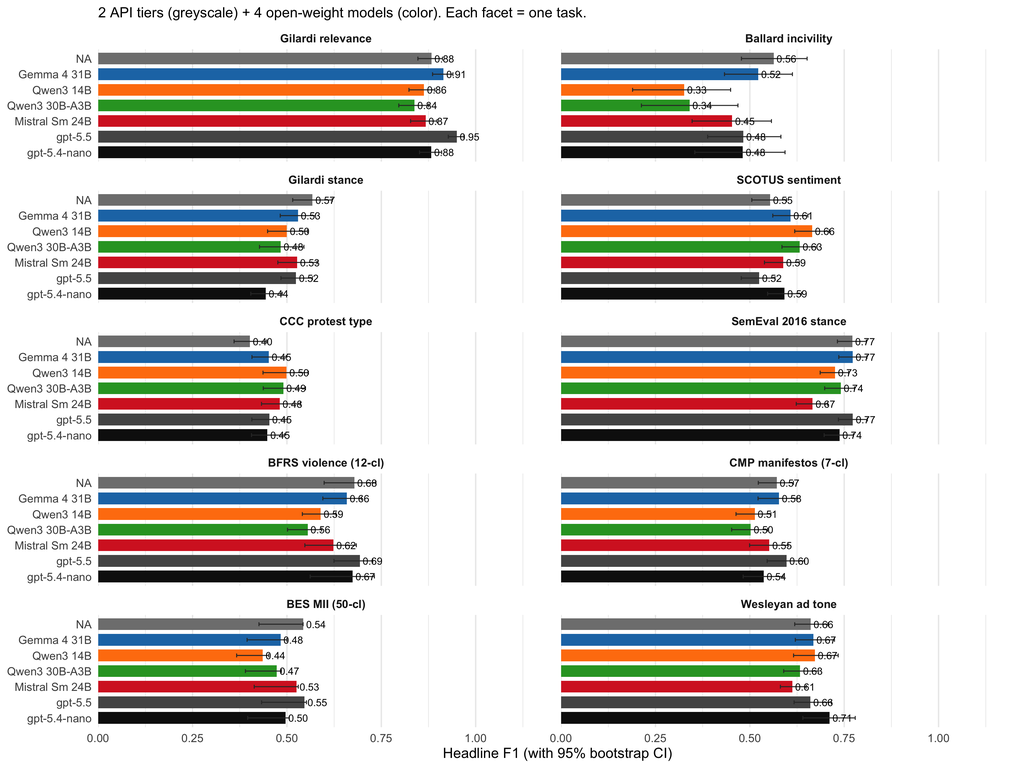

Figure 2: Headline F1 per (task, model). Whiskers = 95% paired-by-item bootstrap CIs (1000 iterations). Models whose CIs overlap on a given task are statistically indistinguishable on that task. gpt-5.4-nano (black) and gpt-5.5 (medium grey) are the two API tiers, both with reasoning_effort=medium; local open-weight models are color-coded.

## Figure 3 — Accuracy by model × task

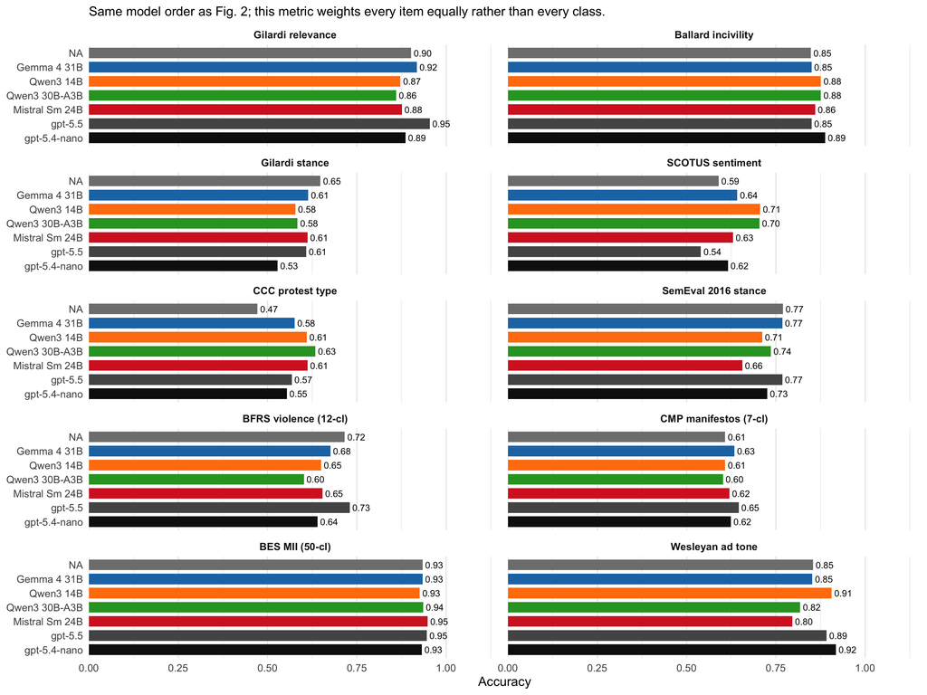

Figure 3: Accuracy per (task, model). Companion to Figure 2 — same model order, same facet layout. Accuracy weights every item equally (vs macro F1 which weights every class equally). On heavily imbalanced tasks (BES MII especially) accuracy and macro F1 diverge sharply; see Finding 4 and the dedicated ‘How close to the human ceiling?’ section below.

**NoteAggregate Figure 1 — Mean ΔF1 vs Mean Latency (per model) (collapsed by default)**

Figures 1 and 2 above show every (task, model) combination. The two figures below condense that to one data point per model by averaging across the 10 tasks — easier to read for a quick “which model should I use by default” take.

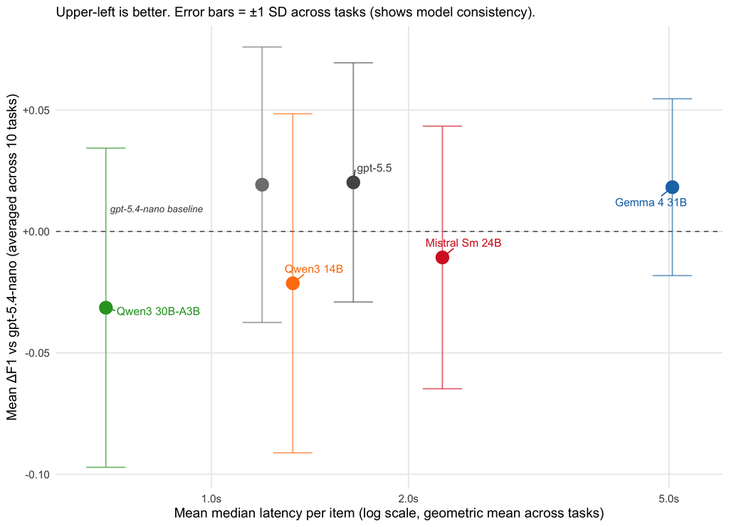

**Reading this figure (v2):** averaged across 10 tasks at v2 N=500, the mean-F1 spread runs from gpt-5.5 (0.621) at the top to Qwen3-30B-A3B (0.569) at the bottom — only 0.052 of total spread. **gpt-5.5 and Gemma 4 31B are essentially tied** (Δ 0.002) at the quality top. **Qwen3-30B-A3B is the speed-Pareto choice** (median 0.61 s/item, faster than any OpenAI tier). **gpt-5.4-nano with medium reasoning** lifts to 3rd at 0.600 — a bigger jump from v1 than any other model in the grid. Error bars on the dot overlay are ±1 SD across tasks (within-model task variance), not bootstrap CIs.

## Mean F1 leaderboard (with per-task spread and bootstrap CIs)

> **How to read this leaderboard.** This is a descriptive index over the 10 tasks in this benchmark, not a stable estimate of overall ability. Mean F1 weights every task equally regardless of label count, class imbalance, construct complexity, or whether the source paper itself used an LLM. The per-task figures (Fig. 2), the model-family breakdown, and the human-ceiling section should be read alongside it. At v2 N=500, per-task differences are mostly within CI overlap — the leaderboard order tracks point estimates aggregated across tasks, which is more stable than any individual task ranking but is not a hypothesis test.

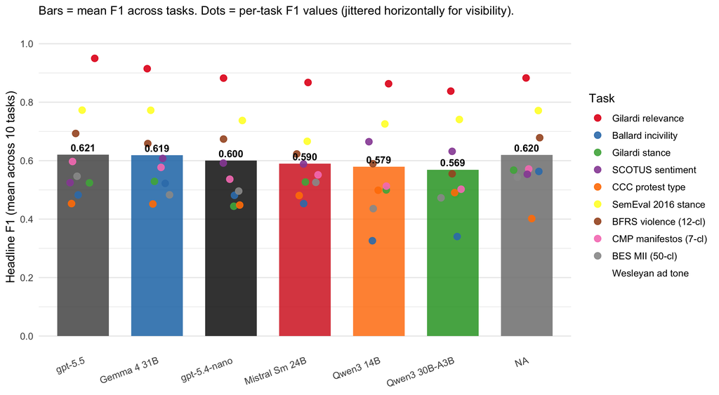

**Reading this figure (v2):** mean F1 across 10 tasks is tightly packed — gpt-5.5 0.621, Gemma 4 31B 0.619, gpt-5.4-nano 0.600, Mistral 0.590, Qwen3-14B 0.579, Qwen3-30B-A3B 0.569 (5-point spread, point estimates only). The **dot spread within each model** is far larger: per-task F1 ranges from 0.30 (Ballard incivility, several models) up to 0.95 (Gilardi relevance, gpt-5.5) and down to 0.37 (BES MII macro, multiple models — but recall MCC reframes BES; see Finding 4). gpt-5.5’s mean is highest by 0.002 over Gemma; per-task answers still vary — Qwen3-14B has the top point estimate on 2 tasks despite a middling overall mean.

## Per-task winners (headline F1, tie-aware)

Tie rule: when 2nd-place model’s CI overlaps the 1st-place CI, both are listed as tied. CIs are 95% paired-by-item bootstrap (1000 iterations). Source-paper human inter-coder reference is shown where available.

Top model(s) per task by headline F1 with 95% CI in brackets. Ties shown when 2nd-place CI overlaps 1st-place CI. Top acc/MCC are for the rank-1 model only. Human ref column: kappa = Cohen’s κ, fleiss = Fleiss’ κ, agree = % coder-vs-coder agreement, acc = coder-vs-gold accuracy.

| task_short | Top model(s) | Top acc | Top MCC | Latency (s) | Human ref |
| --- | --- | --- | --- | --- | --- |
| Gilardi relevance | gpt-5.5 (F1 0.950 [0.93, 0.97]) / Gemma 4 31B (F1 0.915 [0.89, 0.94]) | 0.954 | 0.908 | 1.5 | kappa = 0.88 |
| Ballard incivility | NA (F1 0.563 [0.48, 0.65]) / Gemma 4 31B (F1 0.522 [0.43, 0.61]) / gpt-5.5 (F1 0.483 [0.39, 0.58]) / gpt-5.4-nano (F1 0.481 [0.35, 0.59]) / Mistral Sm 24B (F1 0.453 [0.35, 0.56]) | 0.848 | 0.515 | 1.1 | — |
| Gilardi stance | NA (F1 0.568 [0.52, 0.62]) / Gemma 4 31B (F1 0.529 [0.48, 0.58]) / Mistral Sm 24B (F1 0.527 [0.48, 0.58]) / gpt-5.5 (F1 0.524 [0.48, 0.57]) / Qwen3 14B (F1 0.500 [0.45, 0.55]) / Qwen3 30B-A3B (F1 0.48… | 0.648 | 0.471 | 1.1 | kappa = 0.63 |
| SCOTUS sentiment | Qwen3 14B (F1 0.665 [0.62, 0.71]) / Qwen3 30B-A3B (F1 0.632 [0.59, 0.68]) / Gemma 4 31B (F1 0.608 [0.56, 0.65]) / gpt-5.4-nano (F1 0.592 [0.55, 0.64]) / Mistral Sm 24B (F1 0.589 [0.54, 0.63]) | 0.706 | 0.539 | 1.0 | fleiss = 0.72 |
| CCC protest type | Qwen3 14B (F1 0.499 [0.44, 0.56]) / Qwen3 30B-A3B (F1 0.491 [0.44, 0.55]) / Mistral Sm 24B (F1 0.481 [0.43, 0.53]) / gpt-5.5 (F1 0.453 [0.41, 0.50]) / Gemma 4 31B (F1 0.452 [0.41, 0.50]) / gpt-5.4-nan… | 0.610 | 0.387 | 4.8 | — |
| SemEval 2016 stance | gpt-5.5 (F1 0.773 [0.73, 0.81]) / Gemma 4 31B (F1 0.772 [0.74, 0.81]) / NA (F1 0.771 [0.73, 0.81]) / Qwen3 30B-A3B (F1 0.741 [0.70, 0.78]) / gpt-5.4-nano (F1 0.737 [0.70, 0.77]) / Qwen3 14B (F1 0.726 … | 0.768 | 0.659 | 1.7 | agree = 0.82 |
| BFRS violence (12-cl) | gpt-5.5 (F1 0.693 [0.62, 0.73]) / NA (F1 0.679 [0.60, 0.74]) / gpt-5.4-nano (F1 0.674 [0.56, 0.73]) / Gemma 4 31B (F1 0.659 [0.60, 0.70]) / Mistral Sm 24B (F1 0.623 [0.55, 0.68]) / Qwen3 14B (F1 0.590… | 0.730 | 0.691 | 2.3 | — |
| CMP manifestos (7-cl) | gpt-5.5 (F1 0.597 [0.55, 0.65]) / Gemma 4 31B (F1 0.577 [0.52, 0.62]) / NA (F1 0.572 [0.52, 0.62]) / Mistral Sm 24B (F1 0.552 [0.50, 0.60]) / gpt-5.4-nano (F1 0.537 [0.48, 0.59]) / Qwen3 14B (F1 0.513… | 0.646 | 0.545 | 2.0 | — |
| BES MII (50-cl) | gpt-5.5 (F1 0.547 [0.43, 0.55]) / NA (F1 0.543 [0.43, 0.54]) / Mistral Sm 24B (F1 0.526 [0.41, 0.53]) / gpt-5.4-nano (F1 0.496 [0.40, 0.51]) / Gemma 4 31B (F1 0.483 [0.39, 0.50]) / Qwen3 30B-A3B (F1 0… | 0.946 | 0.934 | 1.0 | acc = 0.87 |
| Wesleyan ad tone | gpt-5.4-nano (F1 0.711 [0.64, 0.78]) / Qwen3 14B (F1 0.673 [0.62, 0.73]) / Gemma 4 31B (F1 0.669 [0.62, 0.72]) / NA (F1 0.661 [0.62, 0.71]) / gpt-5.5 (F1 0.661 [0.62, 0.72]) / Qwen3 30B-A3B (F1 0.633 … | 0.918 | 0.808 | 0.7 | agree = 0.94 |

**NoteFull summary table (collapsed by default)**

All 60 (task, model) observations sorted by task then by headline F1 descending. GPU-hours per 1000 items reported for Ollama models only; OpenAI shown as ‘—’.

| Task | Model | Headline F1 [95% CI] | Accuracy | Median latency (s) | GPU-h / 1k | Parse err | Provenance | N |
| --- | --- | --- | --- | --- | --- | --- | --- | --- |
| Gilardi relevance | gpt-5.5 | 0.950 [0.93, 0.97] | 0.954 | 1.54 | — | 0% | Verbatim | 500 |
| Gilardi relevance | Gemma 4 31B | 0.915 [0.89, 0.94] | 0.918 | 4.80 | 1.334 | 0% | Verbatim | 500 |
| Gilardi relevance | NA | 0.883 [0.85, 0.91] | 0.902 | 1.14 | — | 0% | Verbatim | 500 |
| Gilardi relevance | gpt-5.4-nano | 0.882 [0.85, 0.91] | 0.886 | 0.68 | — | 0% | Verbatim | 500 |
| Gilardi relevance | Mistral Sm 24B | 0.868 [0.83, 0.90] | 0.876 | 2.10 | 0.582 | 0% | Verbatim | 500 |
| Gilardi relevance | Qwen3 14B | 0.863 [0.82, 0.89] | 0.872 | 1.12 | 0.310 | 0% | Verbatim | 500 |
| Gilardi relevance | Qwen3 30B-A3B | 0.838 [0.80, 0.88] | 0.860 | 0.62 | 0.172 | 0% | Verbatim | 500 |
| Ballard incivility | NA | 0.563 [0.48, 0.65] | 0.848 | 1.12 | — | 0% | Derived | 500 |
| Ballard incivility | Gemma 4 31B | 0.522 [0.43, 0.61] | 0.850 | 4.56 | 1.266 | 0% | Derived | 500 |
| Ballard incivility | gpt-5.5 | 0.483 [0.39, 0.58] | 0.850 | 2.03 | — | 0% | Derived | 500 |
| Ballard incivility | gpt-5.4-nano | 0.481 [0.35, 0.59] | 0.888 | 0.71 | — | 0% | Derived | 500 |
| Ballard incivility | Mistral Sm 24B | 0.453 [0.35, 0.56] | 0.860 | 1.83 | 0.509 | 0% | Derived | 500 |
| Ballard incivility | Qwen3 30B-A3B | 0.340 [0.21, 0.47] | 0.876 | 0.60 | 0.168 | 0% | Derived | 500 |
| Ballard incivility | Qwen3 14B | 0.326 [0.19, 0.45] | 0.876 | 1.16 | 0.322 | 0% | Derived | 500 |
| Gilardi stance | NA | 0.568 [0.52, 0.62] | 0.648 | 1.13 | — | 0% | Verbatim | 500 |
| Gilardi stance | Gemma 4 31B | 0.529 [0.48, 0.58] | 0.614 | 4.81 | 1.337 | 0% | Verbatim | 500 |
| Gilardi stance | Mistral Sm 24B | 0.527 [0.48, 0.58] | 0.612 | 2.03 | 0.563 | 0% | Verbatim | 500 |
| Gilardi stance | gpt-5.5 | 0.524 [0.48, 0.57] | 0.608 | 1.92 | — | 0% | Verbatim | 500 |
| Gilardi stance | Qwen3 14B | 0.500 [0.45, 0.55] | 0.578 | 1.09 | 0.302 | 0% | Verbatim | 500 |
| Gilardi stance | Qwen3 30B-A3B | 0.484 [0.43, 0.54] | 0.584 | 0.61 | 0.169 | 0% | Verbatim | 500 |
| Gilardi stance | gpt-5.4-nano | 0.444 [0.40, 0.49] | 0.528 | 0.74 | — | 0% | Verbatim | 500 |
| SCOTUS sentiment | Qwen3 14B | 0.665 [0.62, 0.71] | 0.706 | 0.96 | 0.266 | 0% | Derived | 500 |
| SCOTUS sentiment | Qwen3 30B-A3B | 0.632 [0.59, 0.68] | 0.704 | 0.60 | 0.167 | 0% | Derived | 500 |
| SCOTUS sentiment | Gemma 4 31B | 0.608 [0.56, 0.65] | 0.642 | 4.47 | 1.240 | 0% | Derived | 500 |
| SCOTUS sentiment | gpt-5.4-nano | 0.592 [0.55, 0.64] | 0.616 | 0.71 | — | 0% | Derived | 500 |
| SCOTUS sentiment | Mistral Sm 24B | 0.589 [0.54, 0.63] | 0.630 | 1.85 | 0.514 | 0% | Derived | 500 |
| SCOTUS sentiment | NA | 0.554 [0.51, 0.60] | 0.590 | 1.16 | — | 0% | Derived | 500 |
| SCOTUS sentiment | gpt-5.5 | 0.525 [0.48, 0.57] | 0.540 | 1.95 | — | 0% | Derived | 500 |
| CCC protest type | Qwen3 14B | 0.499 [0.44, 0.56] | 0.610 | 4.77 | 1.324 | 0% | Verbatim-adapted | 500 |
| CCC protest type | Qwen3 30B-A3B | 0.491 [0.44, 0.55] | 0.634 | 1.82 | 0.505 | 0% | Verbatim-adapted | 500 |
| CCC protest type | Mistral Sm 24B | 0.481 [0.43, 0.53] | 0.612 | 8.42 | 2.338 | 0% | Verbatim-adapted | 500 |
| CCC protest type | gpt-5.5 | 0.453 [0.41, 0.50] | 0.568 | 1.49 | — | 0% | Verbatim-adapted | 500 |
| CCC protest type | Gemma 4 31B | 0.452 [0.41, 0.50] | 0.576 | 14.08 | 3.910 | 0% | Verbatim-adapted | 500 |
| CCC protest type | gpt-5.4-nano | 0.448 [0.41, 0.49] | 0.554 | 0.97 | — | 0% | Verbatim-adapted | 500 |
| CCC protest type | NA | 0.402 [0.36, 0.45] | 0.472 | 1.26 | — | 0% | Verbatim-adapted | 500 |
| SemEval 2016 stance | gpt-5.5 | 0.773 [0.73, 0.81] | 0.768 | 1.70 | — | 0% | Derived | 500 |
| SemEval 2016 stance | Gemma 4 31B | 0.772 [0.74, 0.81] | 0.768 | 4.30 | 1.195 | 0% | Derived | 500 |
| SemEval 2016 stance | NA | 0.771 [0.73, 0.81] | 0.770 | 1.31 | — | 0% | Derived | 500 |
| SemEval 2016 stance | Qwen3 30B-A3B | 0.741 [0.70, 0.78] | 0.736 | 0.57 | 0.159 | 0% | Derived | 500 |
| SemEval 2016 stance | gpt-5.4-nano | 0.737 [0.70, 0.77] | 0.726 | 0.70 | — | 0% | Derived | 500 |
| SemEval 2016 stance | Qwen3 14B | 0.726 [0.69, 0.76] | 0.712 | 0.89 | 0.249 | 0% | Derived | 500 |
| SemEval 2016 stance | Mistral Sm 24B | 0.666 [0.62, 0.71] | 0.656 | 1.57 | 0.437 | 0% | Derived | 500 |
| BFRS violence (12-cl) | gpt-5.5 | 0.693 [0.62, 0.73] | 0.730 | 2.35 | — | 0% | Verbatim-adapted | 500 |
| BFRS violence (12-cl) | NA | 0.679 [0.60, 0.74] | 0.716 | 1.16 | — | 0% | Verbatim-adapted | 500 |
| BFRS violence (12-cl) | gpt-5.4-nano | 0.674 [0.56, 0.73] | 0.640 | 0.99 | — | 0% | Verbatim-adapted | 500 |
| BFRS violence (12-cl) | Gemma 4 31B | 0.659 [0.60, 0.70] | 0.676 | 4.80 | 1.334 | 0% | Verbatim-adapted | 500 |
| BFRS violence (12-cl) | Mistral Sm 24B | 0.623 [0.55, 0.68] | 0.654 | 2.00 | 0.555 | 0% | Verbatim-adapted | 500 |
| BFRS violence (12-cl) | Qwen3 14B | 0.590 [0.54, 0.63] | 0.650 | 1.17 | 0.325 | 0% | Verbatim-adapted | 500 |
| BFRS violence (12-cl) | Qwen3 30B-A3B | 0.555 [0.50, 0.59] | 0.602 | 0.68 | 0.188 | 0% | Verbatim-adapted | 500 |
| CMP manifestos (7-cl) | gpt-5.5 | 0.597 [0.55, 0.65] | 0.646 | 2.03 | — | 0% | Derived | 500 |
| CMP manifestos (7-cl) | Gemma 4 31B | 0.577 [0.52, 0.62] | 0.634 | 3.94 | 1.095 | 0% | Derived | 500 |
| CMP manifestos (7-cl) | NA | 0.572 [0.52, 0.62] | 0.608 | 1.22 | — | 0% | Derived | 500 |
| CMP manifestos (7-cl) | Mistral Sm 24B | 0.552 [0.50, 0.60] | 0.620 | 1.58 | 0.440 | 0% | Derived | 500 |
| CMP manifestos (7-cl) | gpt-5.4-nano | 0.537 [0.48, 0.59] | 0.624 | 0.76 | — | 0% | Derived | 500 |
| CMP manifestos (7-cl) | Qwen3 14B | 0.513 [0.46, 0.56] | 0.608 | 1.05 | 0.293 | 0% | Derived | 500 |
| CMP manifestos (7-cl) | Qwen3 30B-A3B | 0.502 [0.45, 0.55] | 0.602 | 0.57 | 0.158 | 0% | Derived | 500 |
| BES MII (50-cl) | gpt-5.5 | 0.547 [0.43, 0.55] | 0.946 | 1.03 | — | 0% | Verbatim-adapted | 500 |
| BES MII (50-cl) | NA | 0.543 [0.43, 0.54] | 0.934 | 1.18 | — | 0% | Verbatim-adapted | 500 |
| BES MII (50-cl) | Mistral Sm 24B | 0.526 [0.41, 0.53] | 0.948 | 1.03 | 0.286 | 0% | Verbatim-adapted | 500 |
| BES MII (50-cl) | gpt-5.4-nano | 0.496 [0.40, 0.51] | 0.932 | 0.62 | — | 0% | Verbatim-adapted | 500 |
| BES MII (50-cl) | Gemma 4 31B | 0.483 [0.39, 0.50] | 0.934 | 2.56 | 0.712 | 0% | Verbatim-adapted | 500 |
| BES MII (50-cl) | Qwen3 30B-A3B | 0.473 [0.39, 0.49] | 0.936 | 0.41 | 0.114 | 0% | Verbatim-adapted | 500 |
| BES MII (50-cl) | Qwen3 14B | 0.436 [0.37, 0.45] | 0.926 | 0.79 | 0.220 | 0% | Verbatim-adapted | 500 |
| Wesleyan ad tone | gpt-5.4-nano | 0.711 [0.64, 0.78] | 0.918 | 0.72 | — | 0% | Derived | 500 |
| Wesleyan ad tone | Qwen3 14B | 0.673 [0.62, 0.73] | 0.906 | 3.11 | 0.863 | 0% | Derived | 500 |
| Wesleyan ad tone | Gemma 4 31B | 0.669 [0.62, 0.72] | 0.852 | 7.92 | 2.201 | 0% | Derived | 500 |
| Wesleyan ad tone | NA | 0.661 [0.62, 0.71] | 0.854 | 1.29 | — | 0% | Derived | 500 |
| Wesleyan ad tone | gpt-5.5 | 0.661 [0.62, 0.72] | 0.892 | 1.01 | — | 0% | Derived | 500 |
| Wesleyan ad tone | Qwen3 30B-A3B | 0.633 [0.59, 0.68] | 0.818 | 1.08 | 0.300 | 0% | Derived | 500 |
| Wesleyan ad tone | Mistral Sm 24B | 0.612 [0.58, 0.65] | 0.796 | 5.41 | 1.503 | 0% | Derived | 500 |

## Implications for practice

Practical defaults for the 10-task scope here, on an Apple Silicon mac2 setup with 6 specific models. Not general claims about “local vs API.”

## Performance by task family

The 10 tasks group into 4 substantively distinct families. Family means are computed by simple averaging of the per-task headline F1 within family (no weighting by item count or task difficulty).

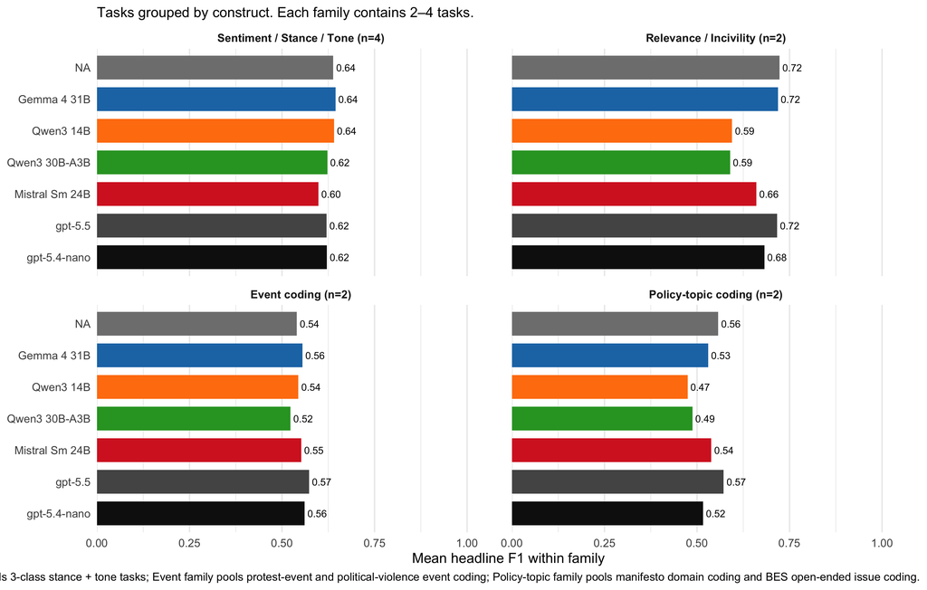

Mean headline F1 by family. Highest per family in each column.

| Model | Event coding (n=2) | Policy-topic coding (n=2) | Relevance / Incivility (n=2) | Sentiment / Stance / Tone (n=4) |
| --- | --- | --- | --- | --- |
| Gemma 4 31B | 0.555 | 0.530 | 0.719 | 0.644 |
| Qwen3 14B | 0.544 | 0.474 | 0.595 | 0.641 |
| NA | 0.540 | 0.557 | 0.723 | 0.639 |
| Qwen3 30B-A3B | 0.523 | 0.488 | 0.589 | 0.622 |
| gpt-5.4-nano | 0.561 | 0.516 | 0.682 | 0.621 |
| gpt-5.5 | 0.573 | 0.572 | 0.716 | 0.621 |
| Mistral Sm 24B | 0.552 | 0.539 | 0.660 | 0.599 |

## Performance by model family (size-based)

In addition to the task-family cut above, this section groups the 6 models into 3 method families by size class — useful when the question is “is the API tier worth it vs local?” rather than “which task family is each model good at?”.

Mean across (10 tasks × N models in family). Local 14B = qwen3:14b only; Local 24-31B = gemma4:31b + qwen3:30b-a3b + mistral-small:24b; OpenAI API = gpt-5.5 + gpt-5.4-nano.

| Family | # models | Mean F1 | Mean acc | Mean MCC | Median latency (s) |
| --- | --- | --- | --- | --- | --- |
| claude-sonnet-4-6 | 1 | 0.620 | 0.734 | 0.594 | 1.17 |
| OpenAI API | 2 | 0.610 | 0.741 | 0.596 | 1.00 |
| Local 24-31B | 3 | 0.592 | 0.736 | 0.569 | 1.92 |
| Local 14B | 1 | 0.579 | 0.744 | 0.568 | 1.10 |

**Reading this table:** the 3 families are within ~0.04 mean F1 of each other on point estimates. The OpenAI API family edges Local 24-31B by ~0.02 (driven by gpt-5.5); Local 14B (a single 14B model) trails Local 24-31B by 0.01 — much closer than the model-size gap would suggest. **Mean accuracy is highest for Local 14B**, which is interesting given the lower mean F1 — qwen3:14b is doing better on the dominant-class items than its macro F1 implies. Within the OpenAI family, gpt-5.5 carries the headline; the cost-efficient nano variant is what makes the family attractive in practice.

## How close to the human ceiling?

Per the related-benchmarks scratchbook (SuperGLUE / Mellon BES pattern): for tasks where the source paper reports a coder-vs-coder agreement or coder-vs-gold accuracy on the same scale as our model accuracy, we can compare the best v2 model directly to the human ceiling. Tasks with κ-only ceilings (Gilardi×2, Ornstein) are excluded — κ is not directly comparable to accuracy.

Tasks where the source paper’s reported human inter-coder ceiling is on the [0,1] accuracy/agreement scale. Best v2 model is the model with the highest accuracy on that task. Gap = best-model-accuracy minus human-ceiling.

| Task | Human ceiling | Best v2 model | Best v2 accuracy | Gap to ceiling |
| --- | --- | --- | --- | --- |
| SemEval 2016 stance | 0.819 (% coder agreement) | NA | 0.770 | -0.048 |
| BES MII (50-cl) | 0.866 (coder-vs-gold acc) | Mistral Sm 24B | 0.948 | +0.082 |
| Wesleyan ad tone | 0.940 (% coder agreement) | gpt-5.4-nano | 0.918 | -0.022 |

## Verbatim-only appendix — does the headline ranking hold?

The 10-task headline mixes 5 verbatim/verbatim-adapted tasks (Gilardi×2, CCC, BFRS, BES MII) with 5 derived tasks. The table below recomputes mean F1 restricted to the 5 verbatim tasks and reports the rank delta.

Mean F1 across all 10 tasks vs the 5 verbatim/verbatim-adapted tasks (Gilardi relevance, Gilardi stance, CCC, BFRS, BES MII). Rank Δ = positive means the model improves under the verbatim-only restriction; negative means the model gets worse without the derived tasks.

| Model | Mean F1 (all 10) | Mean F1 (verbatim 5) | Rank (all 10) | Rank (verbatim 5) | Rank Δ |
| --- | --- | --- | --- | --- | --- |
| gpt-5.5 | 0.621 | 0.633 | 1 | 1 | = |
| NA | 0.620 | 0.615 | 2 | 2 | = |
| Gemma 4 31B | 0.619 | 0.607 | 3 | 3 | = |
| gpt-5.4-nano | 0.600 | 0.589 | 4 | 5 | -1 |
| Mistral Sm 24B | 0.590 | 0.605 | 5 | 4 | +1 |
| Qwen3 14B | 0.579 | 0.577 | 6 | 6 | = |
| Qwen3 30B-A3B | 0.569 | 0.568 | 7 | 7 | = |

**NoteBatched inference (collapsed by default)**

**Motivation.** Pipal, Vogel, Wack & Esser (2026, arXiv:2604.03684) show that packing multiple items into a single API call — “batched prompting” — cuts token costs by 80%+ on production API models with a 1–6 percentage-point accuracy penalty. Their evidence is on 8 API-served LLMs. Our question: does that hold on local open-weight models running on a consumer MacBook (where the relevant cost is wall-clock time, not tokens), and on the v2 OpenAI tier (gpt-5.5 + gpt-5.4-nano with `reasoning_effort=medium`)?

**Design (feasibility-aware).** A pilot showed that batching does **not** help local Ollama models on long-codebook categorical tasks: halterman_ccc × gemma4 × b=10 ran at ~15 s/item, *slower* than the serial baseline. The system-prompt prefill is already long, so packing user inputs after it doesn’t amortize anything that wasn’t already amortized. We therefore re-scoped the local-tier batching study to **batching-feasible tasks**: prompts ≤32 lines and short user inputs.

The grid:

- **Local Ollama tier:** 6 batching-feasible tasks (5 short-prompt carry-over: Gilardi relevance, Gilardi stance, Ballard incivility, SemEval, SCOTUS; plus Wesleyan ad tone, 32-line prompt) × 4 Ollama models × b ∈ {1, 10, 20}, N=500 each.
- **OpenAI tier:** all 10 tasks × {gpt-5.5, gpt-5.4-nano} × b ∈ {1, 10, 20}, N=500 each. OpenAI is fast regardless of prompt length, so we kept the full task set.
- **Infeasibility anchor:** halterman_ccc × gemma4 × b=10 retained as a documented “batching is not feasible here” reference cell.

44,500 batched predictions (89 cells) plus 30,000 b=1 predictions from the v2 serial run. Each batched call packs b items into one prompt and asks for a JSON array of b classifications back. OpenAI uses a strict array-of-object JSON schema; Ollama relies on prompt instructions. Per-item latency is reported as `batch_wall_clock / b` so speedups are directly comparable to b=1.

### Figure — speedup factor per cell

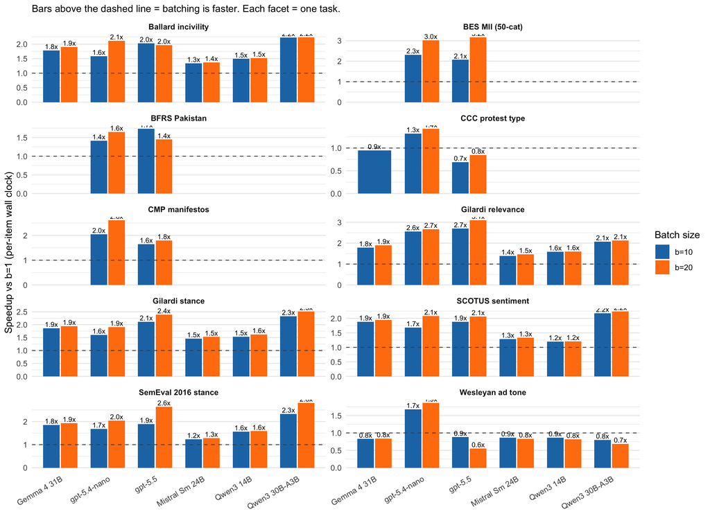

Figure 6: Per-item wall-clock speedup from batching, relative to each cell’s b=1 baseline. Bars are (model, b=10 vs b=20); facets are tasks. Values >1 = faster. The dashed line at 1× is the serial reference. Tasks where Ollama batching is infeasible (long codebooks: CCC, CMP, BFRS, BES MII) show only the OpenAI cells; the halterman_ccc × Gemma × b=10 anchor is included to document the infeasibility result.

**Reading this figure** — the pattern that emerges:

### Figure — accuracy cost: ΔF1 vs b=1 baseline

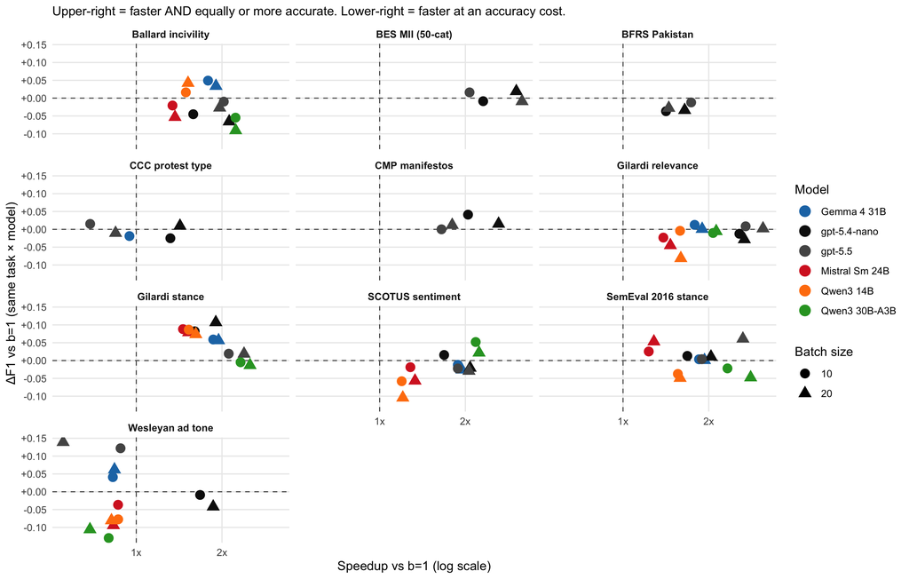

Figure 7: F1 change from batching, relative to each cell’s b=1 baseline. Points above zero = batching preserves or improves accuracy; below zero = accuracy drops.

**Reading this figure** — where each (task, model, b) lands on the speed-vs-accuracy plane:

- **Upper-right quadrant (free speedup):** most cells on the feasible Ollama set; both OpenAI tiers on Gilardi relevance, ballard, chae, ornstein. ΔF1 stays within ±0.03 with 1.5–3× speedup.
- **Lower-right (fast but worse) on Ollama:** Qwen3-14B × Gilardi relevance × b=20 drops −0.08 F1 vs b=1. Pattern: batching at b=20 degrades small/mid-sized local models more than b=10 does. b=10 remains the safer Ollama default.
- **Long-codebook OpenAI cells:** speedup looks favorable in this figure, but parse-error rates (next subsection) make those cells unreliable for production use. F1 here is computed on parsed predictions only; the unparsed items don’t enter the F1 numerator/denominator.

### Parse-error table

Parse errors (percent of items where the model’s batched output could not be parsed into N valid objects) are a direct fragility indicator — they concentrate in a predictable way.

Cells with any parse error at b>1, sorted descending. Cells with zero parse errors are omitted.

| Task | Model | Batch size | Parse err | N |
| --- | --- | --- | --- | --- |
| CCC protest type | gpt-5.5 | 10 | 68% | 500 |
| Wesleyan ad tone | gpt-5.5 | 20 | 48% | 500 |
| CCC protest type | gpt-5.5 | 20 | 40% | 500 |
| BFRS Pakistan | gpt-5.5 | 20 | 32% | 500 |
| BFRS Pakistan | gpt-5.5 | 10 | 28% | 500 |
| Wesleyan ad tone | gpt-5.5 | 10 | 26% | 500 |
| Ballard incivility | gpt-5.5 | 20 | 16% | 500 |
| SemEval 2016 stance | gpt-5.5 | 20 | 16% | 500 |
| Wesleyan ad tone | Qwen3 30B-A3B | 10 | 16% | 500 |
| BFRS Pakistan | gpt-5.4-nano | 10 | 12% | 500 |
| SCOTUS sentiment | gpt-5.5 | 20 | 12% | 500 |
| Ballard incivility | gpt-5.5 | 10 | 10% | 500 |
| CMP manifestos | gpt-5.5 | 10 | 10% | 500 |
| CCC protest type | gpt-5.4-nano | 20 | 8% | 500 |
| BFRS Pakistan | gpt-5.4-nano | 20 | 8% | 500 |
| Gilardi stance | Mistral Sm 24B | 20 | 8% | 500 |
| CCC protest type | gpt-5.4-nano | 10 | 6% | 500 |
| SCOTUS sentiment | Mistral Sm 24B | 20 | 6% | 500 |
| SemEval 2016 stance | Mistral Sm 24B | 20 | 5% | 500 |
| Wesleyan ad tone | Mistral Sm 24B | 20 | 5% | 500 |
| Gilardi stance | gpt-5.5 | 10 | 4% | 500 |
| Gilardi stance | gpt-5.5 | 20 | 4% | 500 |
| Gilardi relevance | Mistral Sm 24B | 20 | 4% | 500 |
| Gilardi stance | Qwen3 14B | 20 | 3% | 500 |
| Gilardi stance | gpt-5.4-nano | 10 | 2% | 500 |
| SCOTUS sentiment | gpt-5.5 | 10 | 2% | 500 |
| Gilardi relevance | Qwen3 14B | 20 | 1% | 500 |
| Wesleyan ad tone | Mistral Sm 24B | 10 | 1% | 500 |
| Ballard incivility | Mistral Sm 24B | 20 | 1% | 500 |
| SemEval 2016 stance | Mistral Sm 24B | 10 | 1% | 500 |
| SemEval 2016 stance | Qwen3 14B | 20 | 1% | 500 |
| Gilardi stance | Mistral Sm 24B | 10 | 0% | 500 |

This is a real production concern: if you batch gpt-5.5 on a long-codebook categorical task at b=20, expect to retry roughly half the items individually. The serial cost saving evaporates once you account for the retry tax.

### Practical recommendations from the batching grid

**NoteCaveats (collapsed by default)**

- **Convenience model set.** Six models (4 local open-weight + 2 OpenAI tiers: gpt-5.5 + gpt-5.4-nano, both at `reasoning_effort=medium`) selected to fit the user’s hardware and budget. No general “API vs local” claim is intended; conclusions are about this specific 6-model grid. v1 used gpt-5.4 + gpt-5.4-nano (both default reasoning); the v2 swap to gpt-5.5 + nano-medium changed the leaderboard.
- **Heterogeneous tasks.** Tasks vary in label count (binary to 50-class), class imbalance (Coronavirus is 38% of items in BES), construct complexity, prompt provenance (verbatim vs derived), and whether the source paper itself used an LLM. Equal-weight task averages should be read as descriptive — not as a stable estimate of “overall ability.”
- **CI ties dominate at N=500.** Under the report’s 95% bootstrap CI tie rule, 5–6 models are tied with the top point estimate on 9 of 10 tasks; only Gilardi relevance has clear separation (2 of 6 tied with top). Cross-model claims rest on point-estimate ordering aggregated across many tasks plus the family breakdown, not on per-task statistical separation.
- **v2 sample structure.** N=500 is the union of v1’s N=250 sample (SEED=20260422) and a v2-new N=250 disjoint sample (SEED+1) drawn from the remaining items. v1 Ollama predictions were carried over; the OpenAI tier was rerun fresh because reasoning_effort changed (v1 default → v2 medium). Item IDs are stable across versions.
- **Halterman CCC was upgraded** from N=50 / 8-class to N=250 / 4-class in v1, and further to N=500 / 4-class in v2. Old 8-class predictions archived at `output/archive/predictions_halterman_ccc_v1_n50.csv`.
- **Thinking mode OFF throughout.** Gemma 4 and Qwen 3 advertise higher numbers with thinking on — these are the local-model floors, not ceilings.
- **Prompt provenance mixed.** Verbatim or near-verbatim from author archives: Gilardi relevance, Gilardi stance, Halterman CCC (subset to test labels), Halterman-Keith BFRS. Derived from codebooks or paper prose: Ballard, SCOTUS, SemEval, Halterman-Keith CMP, BES MII, Wesleyan ad tone. See `docs/prompts_provenance.md` for per-task rating.
- **Ground truth varies in quality.** Gilardi and Ballard use two-coder + adjudication. H&K’s CMP/BFRS/CCC splits use the original public datasets (CMP/MARPOR for manifestos; BFRS for Pakistani violence; the CCC project for protest events). BES MII uses BES production codes (the same labels BES has used in its publications). Wesleyan ad tone uses WMP-trained undergraduate coders (Qualtrics survey with inter-coder reliability checks). SemEval and SCOTUS use published expert-coded data.
- **The 50-class BES task has known F1 instability — MCC is the corrective metric.** Macro F1 over 50 classes where 30+ have <10 items is dominated by noise on rare classes. Accuracy and MCC both report 0.93–0.95 on the same data. We report all three in the summary table; the headline narrative uses MCC for BES specifically.
- **Hardware is specific.** All local inference ran on mac2 (Apple Silicon, 32 GB, Ollama). Throughput on other Apple Silicon or NVIDIA hardware will differ — especially on gemma4:31b, the slowest model here and the one most sensitive to host GPU details.

**NoteArtifacts (collapsed by default)**

- `output/predictions.csv` — 30,000 rows: 10 tasks × 6 models × N=500 single-item predictions (task × model × item × pred + gt + latency + parse_error). v2 grid: 4 Ollama models on (v1 250 + v2-new 250) items each, plus gpt-5.5 + gpt-5.4-nano (medium reasoning) on the full 500.
- `output/summary.csv` — 60 rows per (task, model) with F1 per label + accuracy + **MCC** + bootstrap CIs + GPU-hours-per-1000 (Ollama) + USD-per-1000 (OpenAI) + cost-per-correct columns + latency percentiles; rebuild via `python code/build_summary.py`.
- `code/check_openai_cost.py` and `~/.local/bin/check-openai-cost` — admin-API cost ledger queries (see slash command `/oai-cost`).
- `output/predictions_batched.csv` / `output/summary_batched.csv` — v2 batched-inference study (collapsed section above), 89 cells × N=500 = 44,500 batched predictions; b=1 baseline merged from `predictions.csv`. Feasibility-aware scope: 6 Ollama-feasible tasks × 4 Ollama models, plus all 10 tasks × 2 OpenAI models. Halterman CCC × Gemma × b=10 retained as an “infeasible” anchor.
- `output/archive/v2_batched_partial_2026-04-26/` — partial outputs from the abandoned full-grid batched run (halterman_ccc × all 4 Ollama × b=20 was projected to take 60+ hours); preserved for future resumption.
- `output/archive/n50_2026-04-23/` — prior N=50 snapshot.
- `output/archive/predictions_halterman_ccc_v1_n50.csv` — retired 8-class CCC predictions.
- `output/archive/predictions_v1_n250_2026-04-24.csv` — full v1 N=250 predictions (6-model grid with gpt-5.4 + default-reasoning nano).
- `candidates.yaml` — task-candidate registry; H&K bundle promoted to `already_run`; `wesleyan_creative_ads_2022` `already_run`; `cbp_congressional_bills_cap` `partial` (blocked on user CBP download); `burst_state_legislatures_cap` deprioritized.
- `quality_reports/plans/2026-04-24_benchmark-expansion.md` — drove the v1 expansion. v2 plan in chat history (rerun + softening pass + MCC + cost-per-correct + model-family + human-ceiling additions).
- `quality_reports/related_benchmarks.qmd` (gitignored) — research scratchbook informing the v2 metric and section additions.